# Regression Analysis

Let us remind that

$$SSE = \sum_{i=1}^n\varepsilon_i^2, \quad \quad MSE = \frac{SSE}{n - r} = \frac{SSE}{n - 2}$$

```r
> SSE <- sum(e^2); SSE
[1] 272.4312
> n <- length(MaxRate)
> MSE <- SSE / (n - 2); MSE
[1] 20.95625
```

The **Residual Standard error** is
$$RSE = S_\varepsilon = \sqrt{MSE} = \sqrt{\frac{SSE}{n-2}} = 4.578$$

```r
> s <- sqrt(MSE); s
[1] 4.577799
```

or we can extract it via the function $summary$

```r
> summary(lmResult)

Call:
lm(formula = y ~ x)

Residuals:
    Min      1Q  Median      3Q     Max
-8.9258 -2.5383  0.3879  3.1867  6.6242

Coefficients:
             Estimate Std. Error t value Pr(>|t|)
(Intercept) 210.04846    2.86694   73.27  < 2e-16 ***
x            -0.79773    0.06996  -11.40 3.85e-08 ***
---
Signif. codes:  0 '***' 0.001 '**' 0.01 '*' 0.05 '.' 0.1 ' ' 1

Residual standard error: 4.578 on 13 degrees of freedom
Multiple R-squared:  0.9091,    Adjusted R-squared:  0.9021
F-statistic:   130 on 1 and 13 DF,  p-value: 3.848e-08
```

7. Via the function $summary$ we can estimate also the coefficient of deteremination
   $$cor^2(X,Y) = 1 - \frac{\mathbb{E}\varepsilon^2}{\mathbb{D}Y}$$

Note that it is **Adjusted R-squared: 0.9021** as far as MSE has denominator $n-2$ and we cannot cancel it with the denominator $n-1$ of the estimator $S_Y^2 = \frac{1}{n-1}\sum_{i=1}^n(Y_i - \bar{Y}_n)^2$ of $\mathbb{D}Y$.

The coefficient is close to 100%, therefore, we can say that the independent variable $X$- the age is important for the value of the dependent variable $Y$ - the maximum heart rate. We can determine it also via the formula

```r
> Rsquare <- 1 - MSE/var(MaxRate); Rsquare
[1] 0.9021041
```

If we consider these denominators as equal, then we can cancel them and obtain **Multiple, R-squared: 0.9091**. It does not takes into account that the denominators of the estimators $MSE=S_\varepsilon^2 = \frac{SSE}{n-2}$ and $S_Y^2 = \frac{1}{n-1}\sum_{i=1}^n(Y_i - \bar{Y}_n)^2$ are different and computes
$$Multiple R-squared = 1 - \frac{SSE}{\sum_{i=1}^n(Y_i - \bar{Y}_n)^2} = 0.9090967$$

```r
> Rsq<-1 - SSE/sum((MaxRate - mean(MaxRate))^2); Rsq
[1] 0.9090967
```

or

```r
> Rsquare <- cov(Age, MaxRate)^2/(var(Age)*var(MaxRate)); Rsquare
[1] 0.9090967
```

or

```r
> Rsquare <- cor(Age, MaxRate)^2; Rsquare
[1] 0.9090967
```

8. In order to check if $\mathbb{E}\varepsilon = 0$ we use $t-test$.

$H_0: \mathbb{E}\varepsilon = 0$

$H_0: \mathbb{E}\varepsilon \not= 0$

```r
> t.test(e, mu = 0)

    One Sample t-test

data:  e
t = -6.6543e-15, df = 14, p-value = 1
alternative hypothesis: true mean is not equal to 0
95 percent confidence interval:
 -2.442884  2.442884
sample estimates:
    mean of x
-7.579123e-15
```

$p-value = 1 > 0.05 = \alpha$, so we have no evidence to reject $H_0$.

1. The next step is to test the assumptions of the model that the residuals are i.i.d. normally distributed $\epsilon_i \in N(0, \sigma_\varepsilon^2)$

First we make the normal qq-plot

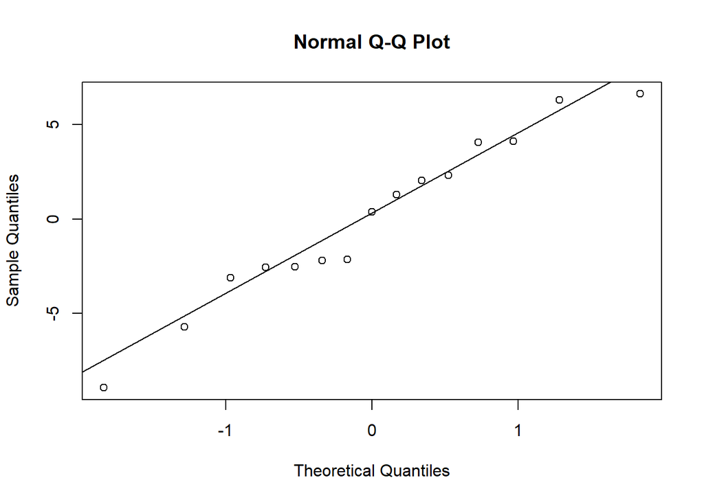

```r
> qqnorm(e)
> qqline(e)
```

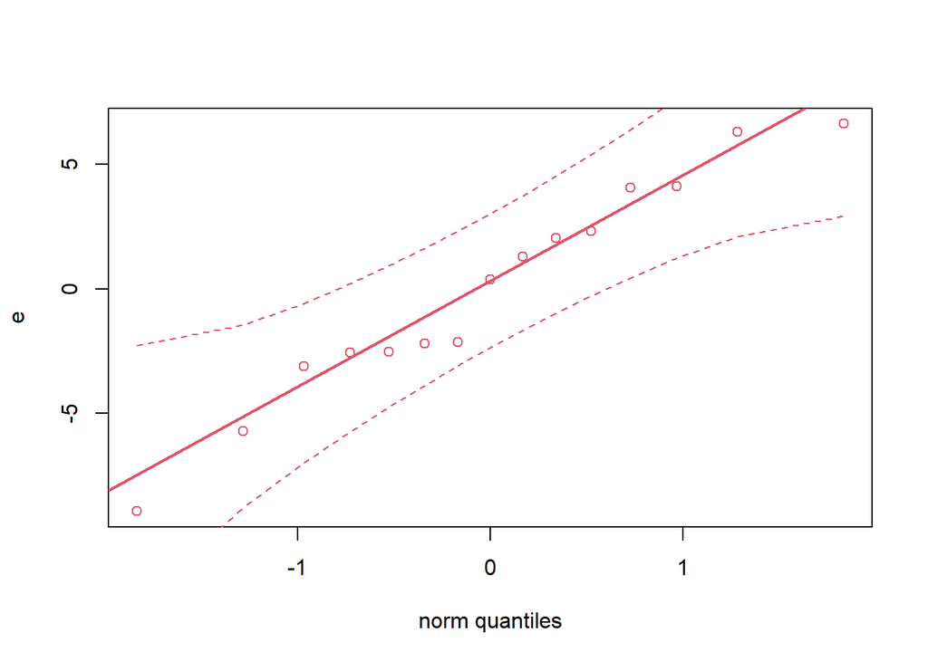

```r
> library(StatDA)
Warning: package 'StatDA' was built under R version 4.0.3
Loading required package: sgeostat
Warning: package 'sgeostat' was built under R version 4.0.3
Registered S3 method overwritten by 'geoR':
  method         from
  plot.variogram sgeostat
> qqplot.das(e)
```

We can perform Shapiro test

$H_0: \varepsilon$ is normally distributed

$H_A: \varepsilon$ is not normally distributed

```r
> shapiro.test(e)

    Shapiro-Wilk normality test

data:  e
W = 0.96302, p-value = 0.7447
```

The $p-value = 0.7447 > 0.05 = \alpha$, so we have no evidence to reject $H_0$.

We can be check all this graphically by

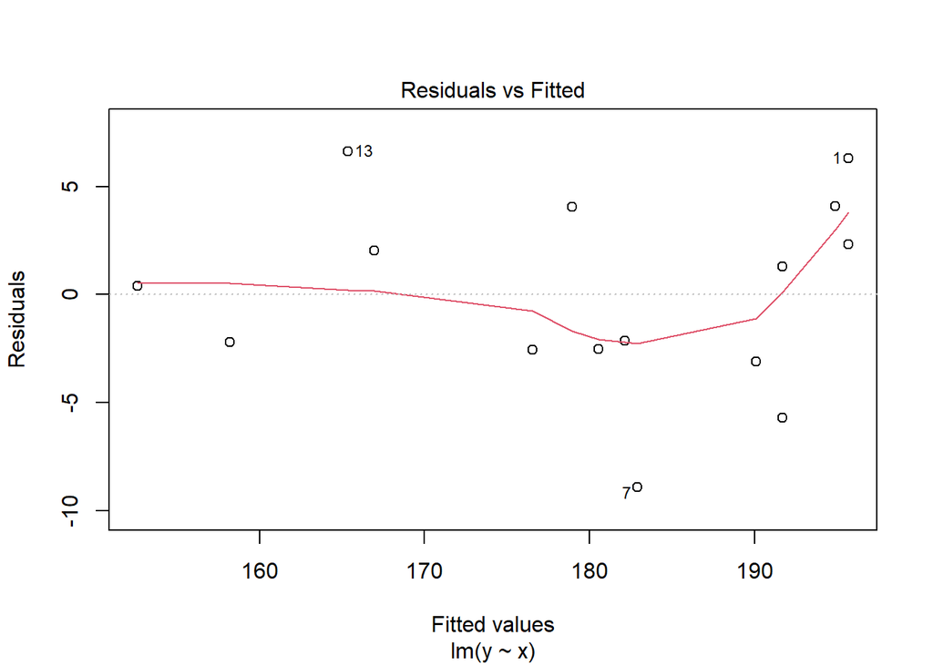

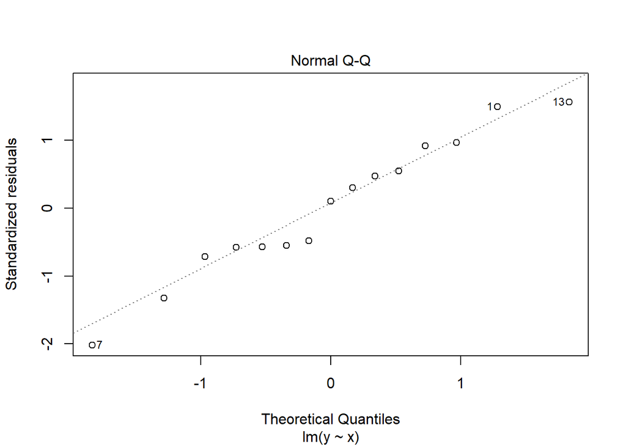

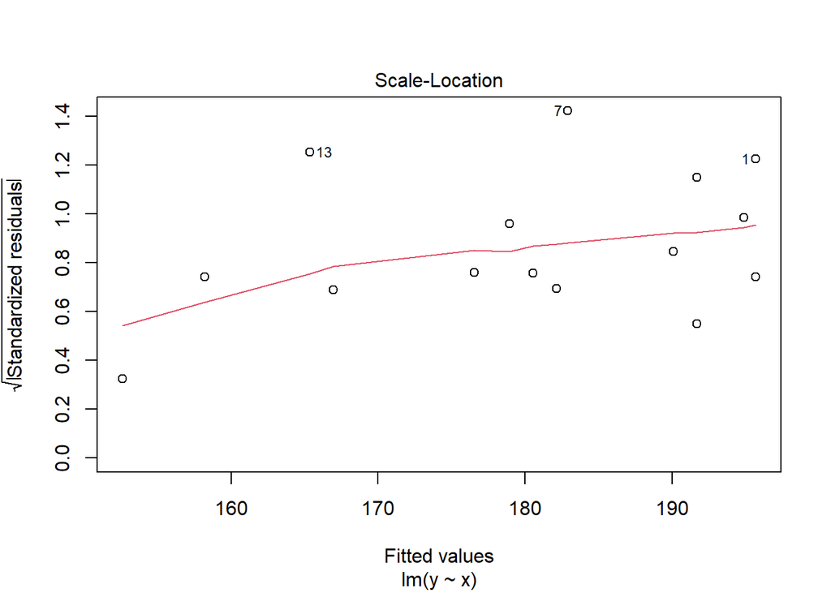

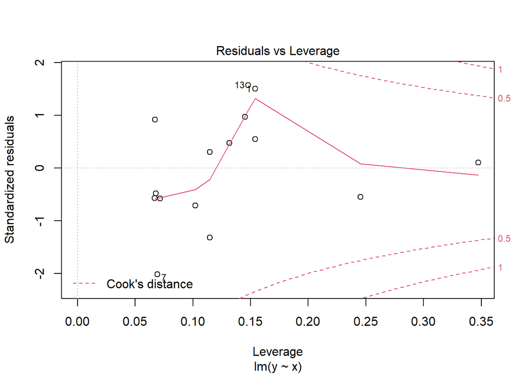

```r
> plot(lmResult)
```

Graphic

- 1 - shows **Residuals vs. fitted** graph. This plots the fitted $\hat{Y}$ against the residuals. Look for spread around the line $y = 0$. This graph help us **check if there is obvious trend for the residuals** or it replaces the test of the hypothesis $H_0: \mathbb{E}\varepsilon = 0$ that we already did.
- 2 - represent **Normal qqplot**. This graph help us **check if the residuals are normally distributed**.
- 3 - shows **Scale location** - square root of the standardized residuals. This graph help us to check if the variance of the error term is a constant, which is the same to observe **homo-** or **heteroscedasticity**. Moreover it helps us to recognize **the largest residuals by looking at the tallest points**.
- 4 - shows **Cook’s distance**. This plot help us **identify points which have a lot of influence in the regression line**.

**Cook’s distance of the $j$-th observation** is
$$D_j = \frac{\sum_{i = 1}^{n}{(\hat{Y_i} - \hat{Y_i}^{(j)})^2}}{2MSE}$$
where $\hat{Y_i}^{(j)}$ is the expected value of $Y$ given $X_i$ when the simple regression model is built up without the $j$-th observation.

Or we can use the pictures from the `simple.lm` function

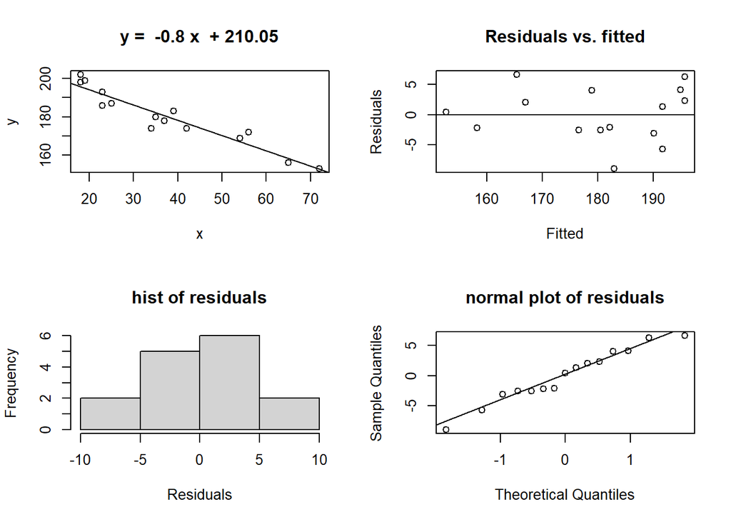

```
Call:
lm(formula = y ~ x)

Coefficients:
(Intercept)            x
   210.0485      -0.7977
```

```r
> simple.lm(Age, MaxRate, show.residuals = TRUE)
```

# Simpson’s paradox

When we analyze the results from the regression analysis we have to take in mind the possibility for the following **Simpson’s_paradox**

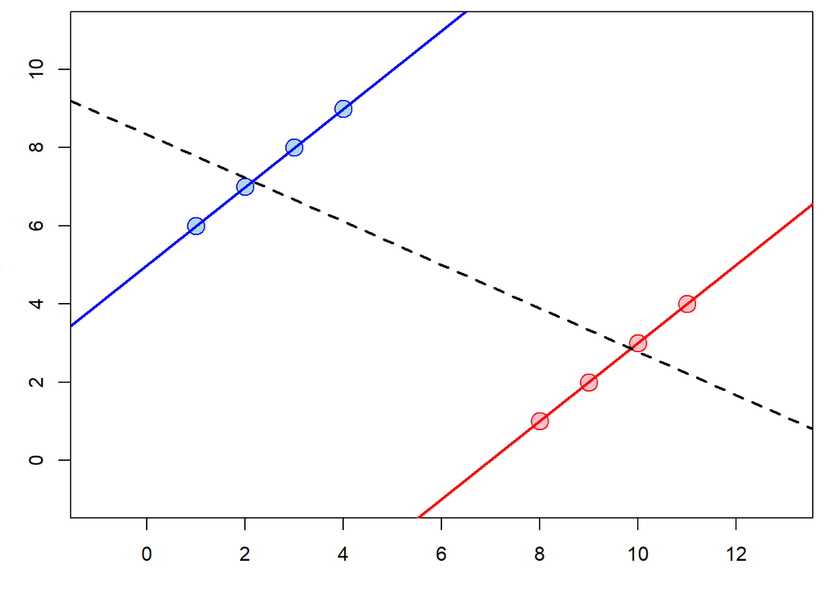

```r
> x1 <- c(1,2,3,4)
> y1 <- x1 + 5
> x2 <- x1 + 7
> y2 <- x2 - 7
> x <- c(x1,x2)
> y <- c(y1,y2)
> par(mar = c(3,3,0.5,0.5))
> plot(x,y, cex = 2, pch = 21, col = rep(c("blue", "red"), each=4), bg = rep(c("lightblue", "pink"), each=4), xlim = range(x) + c(-2,2), ylim = range(y)+ c(-2,2))
> abline(lm(y1 ~ x1), col="blue", lwd=2)
> abline(lm(y2 ~ x2), col="red", lwd=2)
> abline(lm(y  ~ x), lwd=2, lty=2)
```

In such cases it is better to divide the population in subgroups and then to perform regression analysis in any of these groups.

# Confidence intervals for $\mathbb{E}(Y|X = x)$ and $(Y|X = x)$

The regression line is used to predict the value of $Y$ for a given $X$, or the average value of $Y$ for a given $X$ and we would like to know how accurate this prediction is. **Confidence interval** do these.

The estimator of the mean value of $Y$ given $X = X_i$ has a **standard error** of
$$SE(\hat{Y}_i) = S_\varepsilon \sqrt{\frac{1}{n} + \frac{(X_i - \bar{X}_n)^2}{\sum_{j=1}^n{(X_j - \bar{X}_n)^2}}}$$

Therefore, the confidence interval is
$$[\hat{Y}_i - t_{1-\frac{\alpha}{2}; n-r}*SE(\hat{Y}_i); \quad \hat{Y}_i - t_{1-\frac{\alpha}{2}; n-r}*SE(\hat{Y}_i)]$$
$$[\beta_0 + \beta_1X_i - t_{1-\frac{\alpha}{2}; n-r}*SE(\hat{Y}_i); \quad \beta_0 + \beta_1X_i - t_{1-\frac{\alpha}{2}; n-r}*SE(\hat{Y}_i)]$$

## Example 2.

Compute and plot 90% confidence intervals for $\mathbb{E}(Y|X = X_i)$ in the previous example.

Solution.

The function `predict` computes the estimators for $\mathbb{E}(Y|X = X_i)$ (the fitted values) and the corresponding confidence intervals.

```r
> pr = predict(lmResult, interval = "confidence", level = 0.90)
> head(pr)
       fit      lwr      upr
1 195.6894 192.5083 198.8705
2 195.6894 192.5083 198.8705
3 194.8917 191.8028 197.9805
4 191.7007 188.9557 194.4458
5 191.7007 188.9557 194.4458
6 190.1053 187.5137 192.6969
```

The function `simple.lm(show.ci = TRUE, ...)` plots these confidence intervals via solid lines. The following script produces a graph with $90\%$ confidence bands drawn.

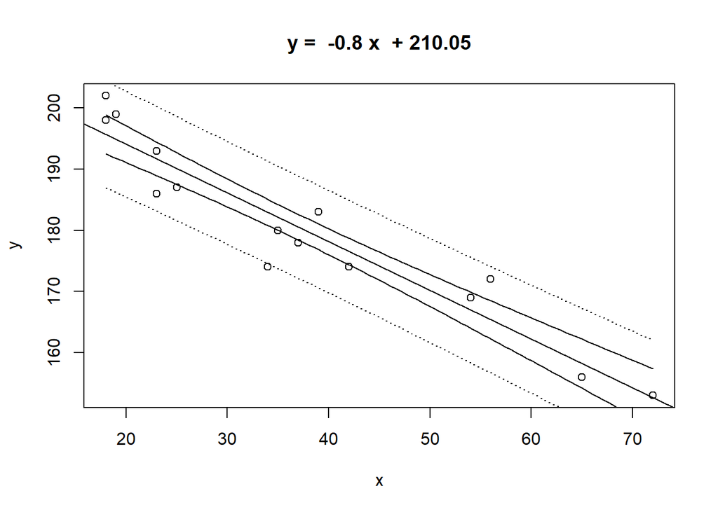

```
Call:
lm(formula = y ~ x)

Coefficients:
(Intercept)            x
   210.0485      -0.7977
```

```r
> simple.lm(Age, MaxRate, show.ci = TRUE, conf.level = 0.90)
```

Dashed lines are confidence intervals for unique values $Y|X=X_i$ based on the fact that if the assumptions of the model are satisfied $\varepsilon_i \in N(0, \sigma_\varepsilon^2)$. As far as the confidence intervals for the next value of the error term is
$$\left[\bar{\varepsilon}_n-t_{1-\frac{\alpha}{2}; n-1} S_\varepsilon \sqrt{1 + \frac{1}{n}}; \bar{\varepsilon}_n+t_{1-\frac{\alpha}{2}; n-1} S_\varepsilon \sqrt{1 + \frac{1}{n}}\right]$$
if the condition $\mathbb{E}\varepsilon = 0$ is satisfied, then there is no statistically signifficant difference between $\bar{\varepsilon}_n$ and $0$, therefore, we can use
$$\left[-t_{1-\frac{\alpha}{2}; n-1} S_\varepsilon \sqrt{1 + \frac{1}{n}}; +t_{1-\frac{\alpha}{2}; n-1} S_\varepsilon \sqrt{1 + \frac{1}{n}}\right]$$
and the confidence interval for the values of $(Y|X = X_i) = \beta_0 +\beta_1X_i + \varepsilon_i$ are
$$\left[\beta_0 +\beta_1X_i-t_{1-\frac{\alpha}{2}; n-1} S_\varepsilon \sqrt{1 + \frac{1}{n}}; \beta_0 + \beta_1X_i+t_{1-\frac{\alpha}{2}; n-1} S_\varepsilon \sqrt{1 + \frac{1}{n}}\right]$$

## Example 3.

In the previous example determine 90% confidence intervals for the mean of the maximum heart rate for persons at age 30, 40, 50.

Solution.

```r
> library(UsingR)
> lmResult <- simple.lm(Age, MaxRate)
```

```r
> e<-resid(lmResult)
> SSE <- sum(e^2); SSE
[1] 272.4312
> n <- length(MaxRate)
> MSE <- SSE / (n - 2); MSE
[1] 20.95625
> Seps<-sqrt(MSE)
> ci30<-yhat30 + c(-1,1)*Seps*sqrt(1/n+(30-mean(Age))/sum((Age-mean(Age))^2)); ci30
[1] 184.9500 187.2834
> ci40<-yhat40 + c(-1,1)*Seps*sqrt(1/n+(40-mean(Age))/sum((Age-mean(Age))^2)); ci40
[1] 176.9519 179.3269
> ci50<-yhat50 + c(-1,1)*Seps*sqrt(1/n+(50-mean(Age))/sum((Age-mean(Age))^2)); ci50
[1] 168.9542 171.3701
```

## Example 4.

In the previous example determine 90% confidence intervals for the next observed maximum heart rate for persons at age 30, 40, 50.

```r
> library(UsingR)
> lmResult <- simple.lm(Age, MaxRate)
```

```r
> e<-resid(lmResult)
> SSE <- sum(e^2); SSE
[1] 272.4312
> n <- length(MaxRate)
> MSE <- SSE / (n - 2); MSE
[1] 20.95625
> Seps<-sqrt(MSE)
> ci30<-yhat30 + c(-1,1)*Seps*sqrt(1/n+1); ci30
[1] 181.3887 190.8446
> ci40<-yhat40 + c(-1,1)*Seps*sqrt(1/n+1); ci40
[1] 173.4115 182.8673
> ci50<-yhat50 + c(-1,1)*Seps*sqrt(1/n+1); ci50
[1] 165.4342 174.8901
```

When compare the results from this and the previous task we see that the confidence interval for unique values are wider than those for the corresponding means.

# Statistical inference related with simple linear regression models

## Confidence intervals for $\mathbb{E}\beta_1$ and hypothesis testing related with the slope $\beta_1$ of the regression line

If we consider the unbiased estimator $\hat{\beta}_1$ of $\beta_1$ as a random variable and if the assumptions of the model are satisfied (inclusively the requirement for the normality of the residual term), then we can compute confidence intervals for $\mathbb{E}\hat{\beta}_1 = \beta_1$ and we can test the hypothesis if $\beta_1$ is equal to a given constant.

The most frequently we test if $\beta_1 = 0$ which means that the independent variable $X$ has no statistically significant influence on $Y$. Or this could be one of the ways to say that the model is not adequate.

The **standard error** of the unbiased estimator $\hat{\beta}_1$ of $\beta_1$ is given by
$$SE(\beta_1) := \frac{S_\varepsilon}{\sqrt{\sum{(X_i - \bar{X_n})^2}}}$$
$$\frac{\hat{\beta}_1 - \beta_1}{SE(\beta_1)} \in t(n - 2)$$
Therefore, the corresponding confidence interval for $\beta_1$ is
$$[\hat{\beta}_1 - t_{1-\frac{\alpha}{2}; n-2}SE(\beta_1); \hat{\beta}_1 + t_{1-\frac{\alpha}{2}; n-2}SE(\beta_1)]$$
And for $b_1 = const$ we can test

$H_0 : \beta_1 = b_1$

$H_A : \beta_1 \neq b_1$

Given $\alpha$ the critical area is

$$W_\alpha =\left\{\frac{|\hat{\beta}_1 - b_1|}{SE(\beta_1)} \geq t_{1-\frac{\alpha}{2}; n-2}\right\}$$

## Example 5

In the previous example

1. construct confidence interval for the parameter $\beta_1$.
2. Test the hypothesis that it is equal to $-1$.
3. Test the hypothesis that it is equal to $0$.
1. We compute the required confidence interval via the following function which computes confidence intervals given the corresponding statistics $bhat$ computed from the data, the corresponding quantile $t$ and the corresponding $SE$

```r
> myCI = function(bhat, SE, t) {
+ bhat + c(-1,1)*SE*t
+ }
```

In this case first we have to compute

```r
> library(UsingR)
> lmResult <- simple.lm(Age, MaxRate)
```

```r
> summary(lmResult)

Call:
lm(formula = y ~ x)

Residuals:
    Min      1Q  Median      3Q     Max
-8.9258 -2.5383  0.3879  3.1867  6.6242

Coefficients:
             Estimate Std. Error t value Pr(>|t|)
(Intercept) 210.04846    2.86694   73.27  < 2e-16 ***
x            -0.79773    0.06996  -11.40 3.85e-08 ***
---
Signif. codes:  0 '***' 0.001 '**' 0.01 '*' 0.05 '.' 0.1 ' ' 1

Residual standard error: 4.578 on 13 degrees of freedom
Multiple R-squared:  0.9091,    Adjusted R-squared:  0.9021
F-statistic:   130 on 1 and 13 DF,  p-value: 3.848e-08
> e <- resid(lmResult)
> n<-length(e)
> beta1hat <- (coef(lmResult))[['x']]; beta1hat
[1] -0.7977266
> Seps <- sqrt(sum(e^2)/(n-2))
> SEbeta1 <- Seps / sqrt(sum((Age - mean(Age))^2)); SEbeta1
[1] 0.06996281
> alpha<-0.05
> t <-qt(1-alpha/2, n - 2, lower.tail = TRUE)
> myCI(beta1hat, SEbeta1,t)
[1] -0.9488720 -0.6465811
```

As far as $-1$ is not in this confidence interval we can guess that the following $H_0$ will be rejected, however let us see.

2. We test

$H_0 : \beta_1 = -1$

$H_A : \beta_1 \neq -1$

```r
> const <- -1
> temp <- abs(beta1hat-const)/SEbeta1; temp
[1] 2.891157
> pvalue<-2*pt(temp, n - 2, lower.tail = FALSE); pvalue
[1] 0.01262031
```

The $p-value = 0.01262031 < 0.05 = \alpha$, so it is unlikely for this data the slop to be $-1$ and we reject $H_0$.

3. It will automatically do a hypothesis test for

$H_0 : \beta_1 = 0$ there is no statistically significant dependence between $X$ and $Y$,

which means that there is no slope in the regression line, or which is the same $X$ and $Y$ are linearly uncorrelated.

```r
> summary(lmResult)

Call:
lm(formula = y ~ x)

Residuals:
    Min      1Q  Median      3Q     Max
-8.9258 -2.5383  0.3879  3.1867  6.6242

Coefficients:
             Estimate Std. Error t value Pr(>|t|)
(Intercept) 210.04846    2.86694   73.27  < 2e-16 ***
x            -0.79773    0.06996  -11.40 3.85e-08 ***
---
Signif. codes:  0 '***' 0.001 '**' 0.01 '*' 0.05 '.' 0.1 ' ' 1

Residual standard error: 4.578 on 13 degrees of freedom
Multiple R-squared:  0.9091,    Adjusted R-squared:  0.9021
F-statistic:   130 on 1 and 13 DF,  p-value: 3.848e-08
```

$H_A : \beta_1 \neq 0$

The $p-value < 3.85e-08 < 0.05 = \alpha$, therefore, we reject $H_0$. The linear dependence between $X$ and $Y$ is statistically significant.

## Confidence intervals for $\mathbb{E}\beta_0$ and hypothesis testing related with the intercept $\beta_0$ of the regression line on $Oy$.

The **standard error** of the unbiased estimator $\hat{\beta}_0$ of $\beta_0$ is given by
$$SE(\beta_0) := S_\varepsilon \sqrt{\frac{\sum_{i=1}^n{X_i^2}}{n \sum_{i=1}^n{(X_i - \bar{X_n})^2}}} = S_\varepsilon \sqrt{\frac{1}{n} + \frac{\bar{X_n}^2}{\sum{(X_i - \bar{X_n})^2}}}$$

$$\frac{\hat{\beta}_0 - \beta_0}{SE(\beta_0)} \in t(n - 2)$$
Therefore, the corresponding confidence interval for $\beta_0$ is
$$[\hat{\beta}_0 - t_{1-\frac{\alpha}{2}; n-2}SE(\beta_0); \hat{\beta}_0 + t_{1-\frac{\alpha}{2}; n-2}SE(\beta_0)]$$
And for $b_0 = const$ we can test

$H_0 : \beta_0 = b_0$

$H_A : \beta_0 \neq b_0$

Given $\alpha$ the critical area is

$$W_\alpha =\left\{\frac{|\hat{\beta}_0 - b_0|}{SE(\beta_0)} \geq t_{1-\frac{\alpha}{2}; n-2}\right\}$$

## Example 6

In the previous example

1. construct confidence interval for the parameter $\beta_0$.
2. Test the hypothesis that the regression line goes trough the coordinate origin.
3. Test the hypothesis that it is equal to $220$.
1. In order to compute the required confidence interval we are going to use again our function $myCI$ In this case

```r
> library(UsingR)
> lmResult <- simple.lm(Age, MaxRate)
```

```r
> summary(lmResult)

Call:
lm(formula = y ~ x)

Residuals:
    Min      1Q  Median      3Q     Max
-8.9258 -2.5383  0.3879  3.1867  6.6242

Coefficients:
             Estimate Std. Error t value Pr(>|t|)
(Intercept) 210.04846    2.86694   73.27  < 2e-16 ***
x            -0.79773    0.06996  -11.40 3.85e-08 ***
---
Signif. codes:  0 '***' 0.001 '**' 0.01 '*' 0.05 '.' 0.1 ' ' 1

Residual standard error: 4.578 on 13 degrees of freedom
Multiple R-squared:  0.9091,    Adjusted R-squared:  0.9021
F-statistic:   130 on 1 and 13 DF,  p-value: 3.848e-08
> beta0hat <- (coef(lmResult))[['(Intercept)']];  beta0hat
[1] 210.0485
> SEbeta0 <- Seps * sqrt(sum(Age^2)/(n*sum((Age - mean(Age))^2))); SEbeta0
[1] 2.866939
> myCI(beta0hat, SEbeta0,t)
[1] 203.8548 216.2421
```

As far as $0$ is not in this confidence interval we can guess that the following $H_0$ will be rejected, however let us see.

2. We test

$H_0 : \beta_0 = 0$ which means that there is no intercept of $Oy$ in the regression line.

$H_A : \beta_0 \neq 0$

```r
> const <- 0
> temp <- abs(beta0hat-const)/SEbeta0; temp
[1] 73.26576
> pvalue<-2*pt(temp, n - 2, lower.tail = FALSE); pvalue
[1] 2.124074e-18
```

See also the outputs of `summary(lmResult)`.

The $p-value = 2.124074e-18 < 0.05 = \alpha$, so it is unlikely for this data the intercept to be $0$ and we reject $H_0$.

3. As far as $220$ is outside the built confidence interval we can guess that we will reject the next $H_0$. Now let us automatically test for

$H_0 : \beta_0 = 220$, which means that there is no statistically significant difference between the intercept and 220.

$H_A : \beta_0 \neq 220$

```r
> SEbeta0 <- Seps * sqrt(sum(Age^2) / (n * sum((Age - mean(Age))^2))); SEbeta0
[1] 2.866939
> temp <- abs(beta0hat - 220) / SEbeta0; temp
[1] 3.471138
> pvalue<-2*pt(temp, n - 2, lower.tail = FALSE); pvalue
[1] 0.004136843
```

## Tests for adequacy

Tests for adequacy check if the independent variable $X$ has no statistically significant influence on $Y$.

$H_0:$ The model is not adequate. The linear dependence between $X$ and $Y$ is not statistically significant. I.e. the slope $\beta_1 = 0$.

$H_A:$ The model is adequate. The linear dependence between $X$ and $Y$ is statistically significant. I.e. the slope $\beta_1 \not= 0$.

As you can see for this model the test for adequacy is equivalent to the one for $H_0: \beta_1 = 0$.

However more generally it is an F-test and given $\alpha > 0$ the critical area is
$$W\alpha = \left\{\frac{\frac{SS(\hat{Y})}{r}}{\frac{SSE}{n-r-1}} \geq x_{1-\alpha, F(r; n-r-1)}\right\}$$
Here we have used that
$$\left(\frac{\frac{SS(\hat{Y})}{r}}{\frac{SSE}{n-r-1}}| H_0\right) \in F(r; n-r-1), \quad SS(\hat{Y}):=\sum_{i=1}^n(\hat{Y}_i - \bar{Y}_n)^2, \quad \bar{Y}_n = \bar{\hat{Y}}_n$$
When we divide the numerator and the denumerator to
$$SS(Y):=\sum_{i=1}^n(Y_i - \bar{Y}_n)^2$$
we obtain
$$\frac{\frac{SS(\hat{Y})}{r}}{\frac{SSE}{n-r-1}} =
\frac{\frac{R^2}{r}}{\frac{1-R^2}{n-r-1}}.$$

## Example 7

In the previous example test the simple linear regression model for adequacy.

```r
> library(UsingR)
> lmResult <- simple.lm(Age, MaxRate)
```

```r
> summary(lmResult)

Call:
lm(formula = y ~ x)

Residuals:
    Min      1Q  Median      3Q     Max
-8.9258 -2.5383  0.3879  3.1867  6.6242

Coefficients:
             Estimate Std. Error t value Pr(>|t|)
(Intercept) 210.04846    2.86694   73.27  < 2e-16 ***
x            -0.79773    0.06996  -11.40 3.85e-08 ***
---
Signif. codes:  0 '***' 0.001 '**' 0.01 '*' 0.05 '.' 0.1 ' ' 1

Residual standard error: 4.578 on 13 degrees of freedom
Multiple R-squared:  0.9091,    Adjusted R-squared:  0.9021
F-statistic:   130 on 1 and 13 DF,  p-value: 3.848e-08
```

Here $F-statistic: 130$ is the empirical value of $\frac{\frac{SS(\hat{Y})}{r}}{\frac{SSE}{n-r-1}}$. We use the p-value of the F-statistics $p-value = 3.848*10^{-08} < 0.05 = \alpha$ , therefore, we reject $H_0$. The model is adequate. The linear dependence between $X$ and $Y$ is statistically significant.

Second way to make the same is:

```r
> beta0hat <- (coef(lmResult))[['(Intercept)']];  beta0hat
[1] 210.0485
> beta1hat <- (coef(lmResult))[['x']];  beta1hat
[1] -0.7977266
> r<-1
> yhat<-beta0hat+beta1hat*Age
> SSE <- sum(e^2); SSE
[1] 272.4312
> n <- length(MaxRate)
> SSYhat<-sum((yhat-mean(yhat))^2); SSYhat
[1] 2724.502
> Femp <- (SSYhat/r) / (SSE/(n-r-1)) ; Femp
[1] 130.0091
> Fquantile<-qf(1-alpha, df1=r, df2=n - r - 1);Fquantile
[1] 4.667193
> pvalue<-pf(Femp, df1=r, df2=n - r - 1, lower.tail = FALSE);pvalue
[1] 3.847987e-08
```

The $p-value = 3.847987*10^{-08} < 0.05 = \alpha$, therefore, we reject $H_0$. The model is adequate. The linear dependence between $X$ and $Y$ is statistically significant.

Third way to make the same.

It is faster to use the function `anova`. Its names comes from **Analysis of Variances /Дисперсионния анализ/**

```r
> anova(lmResult)
Analysis of Variance Table

Response: y
          Df  Sum Sq Mean Sq F value    Pr(>F)
x          1 2724.50 2724.50  130.01 3.848e-08 ***
Residuals 13  272.43   20.96
---
Signif. codes:  0 '***' 0.001 '**' 0.01 '*' 0.05 '.' 0.1 ' ' 1
```

Here $F-statistic = 130.01$ is the empirical value of $\frac{\frac{SS(\hat{Y})}{r}}{\frac{SSE}{n-r-1}}$. We use the p-value of the F-statistics $p-value = 3.848*10^{-08} < 0.05 = \alpha$ , therefore, we reject $H_0$. The model is adequate. The linear dependence between $X$ and $Y$ is statistically significant.